# Economist Figure Task

Hédia Tnani

Last compiled on 21 August, 2022

# Technical Assessment: Economist Figure

## The Task

Recreate this figure:

[figure not shown]

The figure was published online [here](https://www.economist.com/graphic-detail/2017/04/06/a-global-decline-in-smoking-masks-regional-variations-between-the-sexes) by The Economist.

## Reproducing the Economist figure

```r
#Loading the libraries
library(tidyverse)
library(dplyr)
library(ggrepel)
library(ggthemes)
```

```r
#Reading the data
smoking_prevalence <- read.csv("./IHME_GBD_2015_SMOKING_PREVALENCE_1980_2015_1/IHME_GBD_2015_SMOKING_PREVALENCE_1980_2015_Y2017M04D05.CSV")
```

```r
#Understanding the data
#How many group ids?
length(unique(smoking_prevalence$age_group_id))
```

```
## [1] 17
```

```r
#How many locations?
length(unique(smoking_prevalence$location_name))
```

```
## [1] 231
```

```r
#How many years?
length(unique(smoking_prevalence$year_id))
```

```
## [1] 36
```

```r
#keeping relevant features
smoking_prev_filtered <- smoking_prevalence %>% select(location_name, sex, age_group_id, year_id, metric, mean) %>% filter (age_group_id == 27,sex %in% c("Male", "Female"), year_id == "1990" | year_id == "2015", metric == "Percent") %>% select(-c(metric, age_group_id)) %>% rename(Mean = mean, Sex = sex, Year =year_id, Location = location_name )
```

```r
# Calculating point change percentage
# point_change_percentage = (New Number - Original Number) * 100
smoking_prev_PerChange = smoking_prev_filtered %>%
  group_by(Location,Sex,Year) %>% summarise(my_Mean = mean(Mean)) %>%
  mutate(First = head(my_Mean,1),
         PercChange = case_when(my_Mean != First ~ (my_Mean - First) * 100,
                 TRUE ~ First* 100))%>%
  filter(Year == 2015)%>%select(-First)%>%
  select(Location, my_Mean,PercChange)
```

```r
# Generating the figure
smoking_prev_w <- pivot_wider(smoking_prev_PerChange,
                               id_cols = Location,
                               names_from = Sex, values_from = PercChange,
                               values_fn = ~mean(.x))  %>% mutate(Group =
                                     if_else(Male >0 & Female > 0,
                               "G1",
                               if_else(Male < 0 & Female > 0,
                                       "G2",if_else(Male < 0 & Female < 0,
                                       "G3",if_else(Male > 0 & Female < 0,
                                       "G4",
                                       "0")))))
```

```r
theEconomist_theme <- function() {
  theme(panel.border = element_blank(),axis.ticks = element_blank(),axis.title = element_text(size = 10),panel.grid.minor = element_blank(), plot.title = element_text(face = "bold"), legend.position="none",plot.caption = element_text(hjust = 0,size=7,margin=margin(20, b = 30)),plot.caption.position = "plot")}

TheEconomistFigure <- function(data, x, y) {
  ggplot(data, aes (x={{x}}, y={{y}},colour = Group)) + geom_point(size = 3, alpha = 0.9) + scale_color_manual(values = c("tomato4", "deepskyblue3", "lightskyblue1", "tomato2"))+
  theme_bw()+
  theEconomist_theme()+
  geom_text_repel(aes(label = Location), data = subset(smoking_prev_w, Location %in% c("South Korea", "Turkey", "Belarus", "Portugal", "Greece", "Bulgaria","Russia", "Kuwait", "Timor-Leste", "Chile", "Macedonia", "Cyprus", "Indonesia", "Azerbaijan","Montenegro", "Saudi Arabia", "Tonga", "India", "Japan", "China", "France", "Britain", "United States","Nepal", "Brazil", "Sweden", "Canada", "Norway", "Iceland", "Denmark")),col = "#6F7378", size = 3,nudge_x = -0.05)+
  geom_hline(yintercept = 0, size = 0.5) +
  geom_vline(xintercept = 0, size = 0.5)+
  annotate("text", label = "Female increase\nmale decrease", col = "deepskyblue3", size = 3.5, fontface = 2, x = -21, y = 8) +
  annotate("text", label = "Female decrease\nmale decrease", col = "deepskyblue3", size = 3.5,fontface = 2, x = -21, y = -15) +
  annotate("text", label = "Female decrease\nmale increase", col = "tomato2", size = 3.5, fontface = 2, x = 7, y = -17) +
  annotate("text", label = "Female increase\nmale increase", col = "tomato4", size = 3.5, fontface = 2, x = 7, y = 7)+
   scale_x_continuous(breaks = seq(from = -25, to = 10, by = 5)) +
  scale_y_continuous(breaks = seq(from = -20, to = 10, by = 5)) +
labs(x = expression(italic("Change in male rate")), y = expression(italic("Change in female rate")), title = "What a drag", subtitle = "Daily smoking prevalence, 1990-2015, percentage-point change",caption = "Source: smoking prevalence and attributable disease burden in 195 countries and territories,\n1990-2015: a systematic analysis from the Global Burden of Disease Study 2015, the Lancet, 2017")}
```

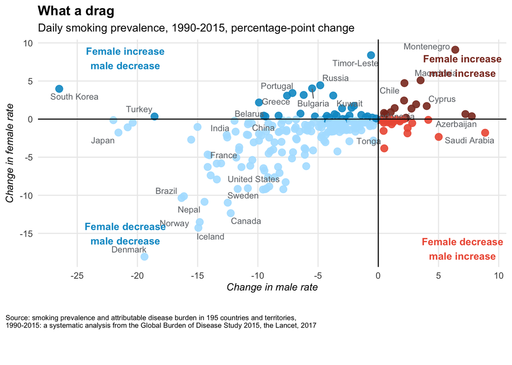

```r
TheEconomistFigure(smoking_prev_w,Male, Female)
```

```r
ggsave("./TheEconomist_figure_task.jpg",last_plot(),width=190, height = 170,units = "mm",dpi = 300)
```

## Submission Checklist

Submit the following: 1. A link to your code (as a GitHub repository) and the finished product. Specifically we want to see: - How you obtained the data (it doesn’t need to be the original data but it should be similar!) # 1st method (failed) I went to the **Supplementary appendix** of the Lancet publication and went to Data sources section. A complete list of sources is available from the [GBD 2015 Data Input Sources Tool](http://ghdx.healthdata.org/gbd-2015/data-input-sources). These data are no longer available on the GHDx.

```
# 2nd method
```

I googled “Smoking prevalence and attributable disease burden” which is part of the title of the Lancet and went through the links. The 4th result was this [link](https://ghdx.healthdata.org/record/ihme-data/gbd-2015-smoking-prevalence-1980-2015) then went to files and downloaded this zip.

These are the pages I checked: [page1](https://stackoverflow.com/questions/64977496/calculate-the-percentage-change-in-r) [page2](https://stackoverflow.com/questions/31812864/obtaining-year-on-year-percentage-change-by-group) [page3](https://stackoverflow.com/questions/61169183/percentage-change-in-values-in-r) [page4](https://stackoverflow.com/questions/48196552/calculate-percentage-change-in-r-using-dplyr) [page5](https://stackoverflow.com/questions/31352685/how-can-i-calculate-the-percentage-change-within-a-group-for-multiple-columns-in)

```
- What did you enjoy the most?
Seeing that once you get the right percentage-point change you get almost the same plot.I enjoyed styling the plot and using the  [R color palette](https://bookdown.org/hneth/ds4psy/D-3-apx-colors-basics.html).

- What did you enjoy the least?
I got frustrated when I didn't find the solution at first and so I had to go back and forth many times.
```